# Convert Euros to local currencies in the EU

10/11/2020

## About the app

The app was created to convert Euros to different currencies in the European Union. Conversion rates were taken from the **R dataset euro**.

After defining the amount of euros to convert and the type of currency, **the app will provide as the output the amount of money the users will get according to their inputs, expressed in the currency selected.**  
**Link to the app**: https://arg-maximiliano.shinyapps.io/EuroConversionRates/

## About the dataset

Conversion rates were taken from the R dataset euro, which contains **conversion rates fixed by the European Union on December 31, 1998**. Conversion rates have more than 2 decimals.

*Conversion rates for each currency available*

```
        ATS         BEF         DEM         ESP         FIM         FRF
  13.760300   40.339900    1.955830  166.386000    5.945730    6.559570
        IEP         ITL         LUF         NLG         PTE
   0.787564 1936.270000   40.339900    2.203710  200.482000
```

*Currencies available*

**Austrian Schilling** (ATS), **Belgian Franc** (BEF), **German Mark** (DEM), **Spanish Peseta** (ESP), **Finnish Markka** (FIM), **French Franc** (FRF), **Irish Punt** (IEP), **Italian Lira** (ITL), **Luxembourg Franc** (LUF), **Dutch Guilder** (NLG) and **Portuguese Escudo** (PTE)

## How the app works?

**Steps required by the user:**

1.Define the amount of euros to convert

2.Select the currency to convert from the list

**Calculation of the output:**

Amount in Euros Selected * Conversion Rate for the Currency Selected = Amount in the Currency Selected

**Example:** by default, the app is setted to convert 100 euros to Austrian Schilling (ATS), which has a conversion rate of 13.760300 ATS per 1 euro. Hence, the output will be:

```
    ATS
1376.03
```

## Screenshot of the app

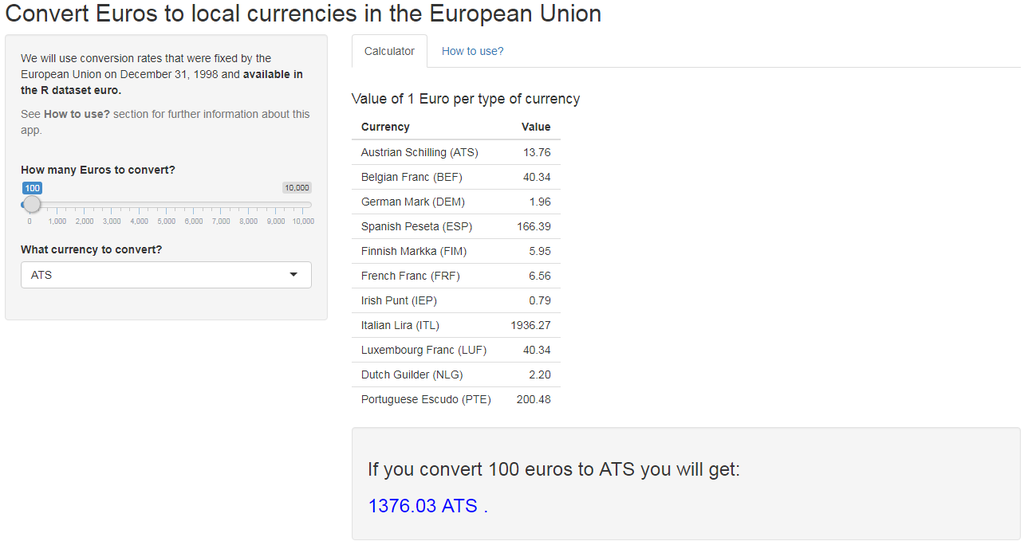

**“How to use?”** section on the second tab of the app provides further information of the app to the users such as *what inputs are expected from them, how the calculations are made and where the data come from.*